# Experimento inSAN

Martín Anaya Quesada

Comenzamos instalando y cargando todos los paquetes necesarios para el experimento.

```r
#install.packages("readxl")
#install.packages("writexl")
#install.packages("dplyr")
#install.packages("netmeta")
#install.packages("mvtnorm")
#install.packages("rgl")


library("readxl") # Leer hojas de cálculo
library("writexl") # Escribir en hojas de cálculo
library("dplyr") # Paquete para la manipulación de datos
library("netmeta") # Modelo de metaanálisis en red
library("mvtnorm") # Se utiliza para generar las probabilidades del rankograma
library("rgl") # Posibilita generar la red de evidencia en 3D
```

La inseguridad alimentaria y nutricional (inSAN) es la condición de aquellas personas que no cuentan con un acceso constante y sostenible a alimentos inocuos que satisfagan sus necesidades nutricionales. En la Agenda 2030, Naciones Unidas propuso uno de los diecesiete Objetivos de Desarrollo Sostenible centrado en acabar con el hambre en el mundo. Sin embargo, muy a menudo, la inSAN es consecuencia de una complicada combinación de condiciones sociales, económicas, políticas e incluso ambientales. Para abordar este problema, es crucial comprender qué factores son sus principales causantes y cómo están relacionados entre ellos.

En el siguiente bloque, se pueden escoger los factores a considerar para el metaanálisis en red, además de los estudios que no han pasado el filtro y deben ser excluidos. El usuario también puede especificar si desea realizar un metaanálisis en red con el modelo de efectos fijos o aleatorios, cuál será el factor de referencia y decidir el indicador del tamaño del efecto más adecuado.

Hay una gran cantidad de factores disponibles. Se recomienda comprobar el archivo data.xlsx para decidir qué factores incluir según el objetivo del metaanálisis.

Los identificadores de los distintos estudios que forman parte de la base de datos son los siguientes: “E1 - Intención Migratoria Guat”, “E2 - ECHO_CA 2020”,“E3 - ECHO_CA 2021”,“E4 - ECHO_CA 2021”,“E5 - ECHO_CA 2022”,“E6 - SMART_Corredor Seco 2010”,“E7 - PROCOMIDA 2015”,“E8 - PROCOMIDA 2014”,“E9 - PROCOMIDA 2010”,“E10 - ECHO 2016”,“E11 - PMA_CA”

```r
archivo_datos <- "data/data.xlsx"

factores_a_analizar <- c("Femenino", "Menos de primaria", "Violencia_sí","Soltero/a", "Más de 4",  "Huerto_no","Embarazadas_sí", "Mala o muy mala",  "Desastres_sí", "AyudaHumanitaria_no")

#Algunos ejemplos de factores interesantes con los que experimentar: "Católico", "Organizaciones_no","Tierra propia_no", "Producción_no", "Menores de 2_sí", "IncrementoPrecios_sí", "Remesas_no", "Otro", "Pobres o extremadamente pobres", "Migración_sí", "PROCOMIDA_no", "Lactantes_sí", "Trabajo_no"

estudios_excluidos <- c("E6 - SMART_Corredor Seco 2010", "E9 - PROCOMIDA 2010")

#"OR", "RR"
tamano_efecto <- "OR"

#En caso de establecer esta variable a FALSE, se realiza el metaanálisis mediante el modelo de efectos fijos (No recomendado puesto que tratamos datos de varios países distintos)
modelo_efectos_aleatorios = TRUE

factor_referencia <- "Femenino"

valores_pequenos <- "bad" #Se debe inicializar esta variable a "good" o "bad" para jerarquizar los factores. En nuestro caso, un tamaño del efecto mayor indica una mayor importancia del factor, luego los tamaños del efecto pequeños clasifican peor ("bad")

semilla = 1234 #Semilla para hacer reproducible el experimento
set.seed(semilla)

#Comprobaciones de los datos introducidos por el usuario para garantizar el funcionamiento del código sin errores
if (!file.exists(archivo_datos)) {
  stop("La ruta a la base de datos no es correcta")
}
if (!(factor_referencia %in% factores_a_analizar)) {
  stop("El factor de referencia no está en la lista de factores a analizar.")
}
if (!(tamano_efecto %in% c("OR", "RR"))) {
  stop("El tamano de efecto seleccionado no es compatible")
}
if (modelo_efectos_aleatorios != TRUE && modelo_efectos_aleatorios != FALSE){
  stop("La variable modelo_efectos_aleatorios debe inicializarse a TRUE o FALSE")
}
if (valores_pequenos != "good" && valores_pequenos != "bad"){
  stop("La variable valores_pequenos debe inicializarse a good o bad")
}

print("Inicialización de las opciones del metaanálisis correcta")
```

```
[1] "Inicialización de las opciones del metaanálisis correcta"
```

En la base de datos existen diversos factores sobre los que no se tiene información, que no están en el formato deseado o que el usuario ha indicado que quiere excluir del metaanálisis. En el siguiente bloque se lee la base de datos (ignorando los estudios excluidos) y mediante la función limpia_datos() se procesan y almacenan en un dataframe que representará toda la evidencia a incluir en la red.

```r
nombres_hojas <- excel_sheets(archivo_datos) #El nombre de cada hoja se corresponde al identificador de la investigación que aporta los datos de dicha hoja.

nombres_hojas <- nombres_hojas[!nombres_hojas %in% estudios_excluidos]


print("Leyendo los estudios: ")
```

```
[1] "Leyendo los estudios: "
```

```r
print(nombres_hojas)
```

```
[1] "E1 - Intención Migratoria Guat" "E2 - ECHO_CA 2020"              "E3 - ECHO_CA 2021"
[4] "E4 - ECHO_CA 2021"              "E5 - ECHO_CA 2022"              "E7 - PROCOMIDA 2015"
[7] "E8 - PROCOMIDA 2014"            "E10 - ECHO 2016"                "E11 - PMA_CA"
```

```r
#datos_estudios es una lista de dataframes, en cada elemento se almacena la información de un estudio
datos_estudios <- lapply(nombres_hojas, function(hoja) {
  if (!(hoja %in% estudios_excluidos)) {
    read_excel(archivo_datos, sheet = hoja)
  }else {
    NULL  #NULL si el estudio ha quedado descartado
  }
})
#Eliminar elementos NULL
datos_estudios <- datos_estudios[!sapply(datos_estudios, is.null)]


#Función para la preparación de datos
limpia_datos <- function(dataframe) {
  #Guardamos las filas que contienen el valor NA (no hay datos sobre este factor)
  filas_na <- which(rowSums(is.na(dataframe)) > 0)

  #Vector con las filas vacías que pretendemos eliminar. La fila anterior es su identificador por lo que también se debe borrar.
  filas_a_eliminar <- unique(c(filas_na - 1, filas_na))

  #Antes de llevar a cabo la eliminación, comprobamos que todos los índices están dentro del tamaño del vector
  filas_a_eliminar <- filas_a_eliminar[filas_a_eliminar > 0 & filas_a_eliminar <= nrow(dataframe)]

  #Eliminamos las filas
  dataframe_filtrado <- dataframe[-filas_a_eliminar, ]

  #Establecemos el identificador de cada columna y su tipo
  colnames(dataframe_filtrado) <- c("Factor", "ISAN_Leve", "ISAN_Severa", "Total")
  dataframe_filtrado$ISAN_Leve <- as.numeric(dataframe_filtrado$ISAN_Leve)
  dataframe_filtrado$ISAN_Severa <- as.numeric(dataframe_filtrado$ISAN_Severa)
  dataframe_filtrado$Total <- as.numeric(dataframe_filtrado$Total)
  return(dataframe_filtrado)
}


datos_estudios_limpios <- lapply(datos_estudios, limpia_datos)
#Seleccionamos únicamente los factores que el usuario ha decidido incluir en el metaanálisis
datos_estudios_limpios <- lapply(datos_estudios_limpios, function(dataframe){
  filter(dataframe, Factor %in% factores_a_analizar)
})


#Asigna el nombre del estudio a cada dataframe
names(datos_estudios_limpios) <- nombres_hojas
print(datos_estudios_limpios)
```

```
$`E1 - Intención Migratoria Guat`
```

| Factor | ISAN_Leve | ISAN_Severa | Total |
| --- | --- | --- | --- |
| Femenino | 78 | 290 | 368 |
| Menos de primaria | 44 | 278 | 322 |
| Más de 4 | 135 | 581 | 716 |
| Mala o muy mala | 57 | 407 | 464 |
| Soltero/a | 61 | 217 | 278 |
| Violencia_sí | 1 | 18 | 19 |
| Desastres_sí | 38 | 273 | 311 |

```
$`E2 - ECHO_CA 2020`
```

| Factor | ISAN_Leve | ISAN_Severa | Total |
| --- | --- | --- | --- |
| Femenino | 2024 | 673 | 2697 |
| Más de 4 | 1259 | 432 | 1691 |
| Violencia_sí | 61 | 31 | 92 |
| AyudaHumanitaria_no | 2147 | 745 | 2892 |
| Embarazadas_sí | 61 | 44 | 105 |

```
$`E3 - ECHO_CA 2021`
```

| Factor | ISAN_Leve | ISAN_Severa | Total |
| --- | --- | --- | --- |
| Femenino | 2397 | 996 | 3393 |
| Más de 4 | 1171 | 547 | 1718 |
| Violencia_sí | 67 | 118 | 185 |
| AyudaHumanitaria_no | 2311 | 1115 | 3426 |
| Embarazadas_sí | 89 | 30 | 119 |

```
$`E4 - ECHO_CA 2021`
```

| Factor | ISAN_Leve | ISAN_Severa | Total |
| --- | --- | --- | --- |
| Femenino | 3026 | 818 | 3844 |
| Más de 4 | 1284 | 344 | 1628 |
| Violencia_sí | 89 | 36 | 125 |
| AyudaHumanitaria_no | 3241 | 855 | 4096 |
| Embarazadas_sí | 100 | 29 | 129 |

```
$`E5 - ECHO_CA 2022`
```

| Factor | ISAN_Leve | ISAN_Severa | Total |
| --- | --- | --- | --- |
| Femenino | 1893 | 444 | 2337 |
| Más de 4 | 796 | 158 | 954 |
| Violencia_sí | 108 | 24 | 132 |
| AyudaHumanitaria_no | 2403 | 486 | 2889 |
| Embarazadas_sí | 60 | 19 | 79 |

```
$`E7 - PROCOMIDA 2015`
```

| Factor | ISAN_Leve | ISAN_Severa | Total |
| --- | --- | --- | --- |
| Femenino | 3892 | 526 | 4418 |
| Más de 4 | 2394 | 337 | 968 |
| Soltero/a | 4221 | 550 | 4776 |
| Embarazadas_sí | 89 | 10 | 99 |
| Huerto_no | 1236 | 157 | 1393 |

```
$`E8 - PROCOMIDA 2014`
```

| Factor | ISAN_Leve | ISAN_Severa | Total |
| --- | --- | --- | --- |
| Embarazadas_sí | 53 | 1 | 54 |

```
$`E10 - ECHO 2016`
```

| Factor | ISAN_Leve | ISAN_Severa | Total |
| --- | --- | --- | --- |
| Femenino | 3717 | 924 | 4641 |
| Más de 4 | 890 | 209 | 1099 |
| AyudaHumanitaria_no | 1202 | 307 | 1509 |

```
$`E11 - PMA_CA`
```

| Factor | ISAN_Leve | ISAN_Severa | Total |
| --- | --- | --- | --- |
| Femenino | 6764 | 6260 | 13024 |
| Menos de primaria | 1326 | 1584 | 2910 |
| Más de 4 | 6116 | 6313 | 12429 |
| Violencia_sí | 4976 | 9497 | 14473 |
| AyudaHumanitaria_no | 5688 | 6495 | 12183 |

```r
#Podemos guardar los datos limpios en un nuevo excel
#write_xlsx(datos_estudios_limpios, "factores_considerados.xlsx")
```

Ahora debemos implementar las funciones para calcular los tamaños del efecto que se pueden utilizar con datos dicotómicos. Aquí se definen dos métodos para computar el Odds Ratio y el Risk Ratio respectivamente. Recordemos que estos valores se deben tomar en escala logarítmica.

Se ha considerado inSAN Moderada/Severa como evento y SAN/inSAN leve como no evento.

```r
#Función para calcular el odds ratio de dos factores
calcular_odds_ratio <- function(a, b, c, d) {
  # a = ISAN_Severa_Factor1
  # b = ISAN_Leve_Factor1
  # c = ISAN_Severa_Factor2
  # d = ISAN_Leve_Factor2

  #Fórmula odds ratio (tomando el logaritmo natural)
  OR <- log((a / b) / (c / d))

  #Fórmula para calcular el error estándar del log(OR)
  se_log_OR <- sqrt(1/a + 1/b + 1/c + 1/d)

  return(list(TE = OR, seTE = se_log_OR))
}

calcular_risk_ratio <- function(a, b, c, d) {
  # a = ISAN_Severa_Factor1
  # b = ISAN_Leve_Factor1
  # c = ISAN_Severa_Factor2
  # d = ISAN_Leve_Factor2

  #Fórmula risk ratio (tomando el logaritmo natural)
  RR <- log((a / (a + b)) / (c / (c + d)))

  #Fórmula para calcular el error estándar del log(RR)
  se_log_RR <- sqrt((1/a) - (1/(a + b)) + (1/c) - (1/(c + d)))

  return(list(TE = RR, seTE = se_log_RR))
}
```

Para realizar el metaanálisis en red con el paquete netmeta, los datos deben aparecer a nivel de contraste. Utilizamos los tamaños del efecto implementados en el bloque anterior para generar las comparaciones necesarias.

```r
  #Dataframe que almacenará los datos en formato compatible con netmeta
  df_contrastes <- data.frame(Estudio = character(),
                         Factor1 = character(),
                         Factor2 = character(),
                         TE = numeric(),
                         seTE = numeric(),
                         stringsAsFactors = FALSE
  )

for (index in seq_along(datos_estudios_limpios)) {
  df = datos_estudios_limpios[[index]]

  #Generar todas las comparaciones posibles entre factores, se almacena en forma de columna
  if (length(unique(df$Factor)) < 2) {
    next  #Si no hay al menos dos factores, no se pueden generar comparaciones
  }
  combinaciones <- combn(df$Factor, 2)


  #Calcular el tamaño del efecto y error estándar para cada comparación
  for (i in 1:ncol(combinaciones)) {
    factor1 <- combinaciones[1, i]
    factor2 <- combinaciones[2, i]

    a <- df$ISAN_Severa[df$Factor == factor1]
    b <- df$ISAN_Leve[df$Factor == factor1]
    c <- df$ISAN_Severa[df$Factor == factor2]
    d <- df$ISAN_Leve[df$Factor == factor2]

    if(tamano_efecto == "OR"){
      resultado <- calcular_odds_ratio(a, b, c, d)
    } else if(tamano_efecto == "RR"){
      resultado <- calcular_risk_ratio(a, b, c, d)
    }

    #Los resultados se almacenan en el dataframe df_contrastes
    df_contrastes <- rbind(df_contrastes, data.frame(
                                          Estudio = names(datos_estudios_limpios)[index],
                                          Factor1 = factor1,
                                          Factor2 = factor2,
                                          TE = resultado$TE,
                                          seTE = resultado$seTE,
                                          stringsAsFactors = FALSE
    ))
  }

}
  #Mostrar los resultados
  print(df_contrastes)
```

| Estudio | Factor1 | Factor2 | TE | seTE |
| --- | --- | --- | --- | --- |
| E1 - Intención Migratoria Guat | Femenino | Menos de primaria | -0.530259383 | 0.20638116 |
| E1 - Intención Migratoria Guat | Femenino | Más de 4 | -0.146303882 | 0.15936551 |
| E1 - Intención Migratoria Guat | Femenino | Mala o muy mala | -0.652589821 | 0.19044593 |
| E1 - Intención Migratoria Guat | Femenino | Soltero/a | 0.044148607 | 0.19305576 |
| E1 - Intención Migratoria Guat | Femenino | Violencia_sí | -1.577199662 | 1.03528950 |
| E1 - Intención Migratoria Guat | Femenino | Desastres_sí | -0.658713539 | 0.21505251 |
| E1 - Intención Migratoria Guat | Menos de primaria | Más de 4 | 0.383955501 | 0.18828960 |
| E1 - Intención Migratoria Guat | Menos de primaria | Mala o muy mala | -0.122330438 | 0.21523303 |
| E1 - Intención Migratoria Guat | Menos de primaria | Soltero/a | 0.574407990 | 0.21754570 |
| E1 - Intención Migratoria Guat | Menos de primaria | Violencia_sí | -1.046940278 | 1.04013458 |

[output cut: 74 more lines]

```r
NA
```

Todo está listo para ajustar el modelo. Para ello, utilizaremos el modelo basado en teoría de grafos que implementa netmeta.

```r
settings.meta(digits = 2, digits.se = 3) #Los tamaños del efecto y sus intervalos de confianza se mostrarán con dos cifras y los errores con tres

#Función para ajustar modelos del paquete netmeta
m.netmeta <- netmeta(TE = TE,
                     seTE = seTE,
                     treat1 = Factor1,
                     treat2 = Factor2,
                     studlab = Estudio,
                     data = df_contrastes,
                     sm = tamano_efecto, #Tamaño del efecto escogido por el usuario
                     fixed = !modelo_efectos_aleatorios,
                     random = modelo_efectos_aleatorios, #Se recomienda utilizar un modelo de efectos aleatorios porque los datos proceden de distintos países
                     reference.group = factor_referencia, #Factor de referencia escogido por el usuario
                     details.chkmultiarm = TRUE, #Imprimir estimaciones inconsistentes
                     #tol.multiarm = 1, #Tolerancia a inconsistencia
                     title = "Modelo de metaanálisis en red",
                     sep.trts = " vs ") #Separador para indicar las comparaciones de la red
```

Con la función summary() podemos imprimir los resultados del ajuste del modelo.

```r
summary(m.netmeta)
```

```
Title: Modelo de metaanálisis en red

Original data (with adjusted standard errors for multi-arm studies):

                                            treat1            treat2    TE  seTE seTE.adj narms multiarm
E1 - Intención Migratoria Guat            Femenino Menos de primaria -0.53 0.206    0.441     7        *
E1 - Intención Migratoria Guat            Femenino          Más de 4 -0.15 0.159    0.316     7        *
E1 - Intención Migratoria Guat            Femenino   Mala o muy mala -0.65 0.190    0.399     7        *
E1 - Intención Migratoria Guat            Femenino         Soltero/a  0.04 0.193    0.406     7        *
E1 - Intención Migratoria Guat            Femenino      Violencia_sí -1.58 1.035    2.419     7        *
E1 - Intención Migratoria Guat        Desastres_sí          Femenino  0.66 0.215    0.463     7        *
E1 - Intención Migratoria Guat            Más de 4 Menos de primaria -0.38 0.188    0.373     7        *
E1 - Intención Migratoria Guat     Mala o muy mala Menos de primaria  0.12 0.215    0.472     7        *
E1 - Intención Migratoria Guat   Menos de primaria         Soltero/a  0.57 0.218    0.480     7        *
E1 - Intención Migratoria Guat   Menos de primaria      Violencia_sí -1.05 1.040    2.859     7        *
E1 - Intención Migratoria Guat        Desastres_sí Menos de primaria  0.13 0.237    0.547     7        *
E1 - Intención Migratoria Guat     Mala o muy mala          Más de 4  0.51 0.171    0.338     7        *
E1 - Intención Migratoria Guat            Más de 4         Soltero/a  0.19 0.174    0.344     7        *
E1 - Intención Migratoria Guat            Más de 4      Violencia_sí -1.43 1.032    2.049     7        *
E1 - Intención Migratoria Guat        Desastres_sí          Más de 4  0.51 0.198    0.392     7        *
E1 - Intención Migratoria Guat     Mala o muy mala         Soltero/a  0.70 0.202    0.435     7        *
E1 - Intención Migratoria Guat     Mala o muy mala      Violencia_sí -0.92 1.037    2.591     7        *
E1 - Intención Migratoria Guat        Desastres_sí   Mala o muy mala  0.01 0.224    0.496     7        *
E1 - Intención Migratoria Guat           Soltero/a      Violencia_sí -1.62 1.038    2.635     7        *
E1 - Intención Migratoria Guat        Desastres_sí         Soltero/a  0.70 0.226    0.504     7        *
E1 - Intención Migratoria Guat        Desastres_sí      Violencia_sí -0.92 1.042    3.004     7        *
E2 - ECHO_CA 2020                         Femenino          Más de 4 -0.03 0.071    0.201     5        *
E2 - ECHO_CA 2020                         Femenino      Violencia_sí -0.42 0.225    0.439     5        *
E2 - ECHO_CA 2020              AyudaHumanitaria_no          Femenino  0.04 0.062    0.190     5        *
E2 - ECHO_CA 2020                   Embarazadas_sí          Femenino  0.77 0.203    0.401     5        *
E2 - ECHO_CA 2020                         Más de 4      Violencia_sí -0.39 0.228    0.461     5        *
E2 - ECHO_CA 2020              AyudaHumanitaria_no          Más de 4  0.01 0.070    0.200     5        *
E2 - ECHO_CA 2020                   Embarazadas_sí          Más de 4  0.74 0.205    0.421     5        *
E2 - ECHO_CA 2020              AyudaHumanitaria_no      Violencia_sí -0.38 0.225    0.436     5        *
E2 - ECHO_CA 2020                   Embarazadas_sí      Violencia_sí  0.35 0.296    0.919     5        *
E2 - ECHO_CA 2020              AyudaHumanitaria_no    Embarazadas_sí -0.73 0.202    0.398     5        *
E3 - ECHO_CA 2021                         Femenino          Más de 4 -0.12 0.064    0.200     5        *
E3 - ECHO_CA 2021                         Femenino      Violencia_sí -1.44 0.158    0.333     5        *
E3 - ECHO_CA 2021              AyudaHumanitaria_no          Femenino  0.15 0.052    0.188     5        *
E3 - ECHO_CA 2021                   Embarazadas_sí          Femenino -0.21 0.214    0.428     5        *
```

[output cut: 162 more lines]

```
Huerto_no           0.94 [0.70; 1.25] -0.44   0.6571
Mala o muy mala     1.73 [1.19; 2.53]  2.84   0.0045
Más de 4            1.02 [0.92; 1.14]  0.44   0.6614
Menos de primaria   1.28 [1.04; 1.58]  2.37   0.0176
Soltero/a           0.93 [0.75; 1.16] -0.62   0.5339
Violencia_sí        1.98 [1.68; 2.34]  8.07 < 0.0001

Quantifying heterogeneity / inconsistency:
tau^2 = 0.0180; tau = 0.1343; I^2 = 74.6% [62.1%; 82.9%]

Tests of heterogeneity (within designs) and inconsistency (between designs):
                    Q d.f.  p-value
Total           90.44   23 < 0.0001
Within designs  58.24   12 < 0.0001
Between designs 32.20   11   0.0007
```

Vamos a analizar los resultados. Como se explicó, el primer paso es estudiar la estructura de la red.

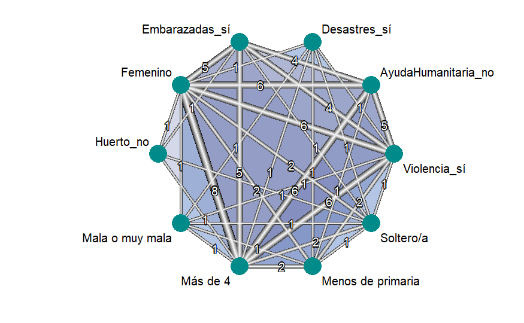

```r
netgraph(m.netmeta, plastic = TRUE, multiarm = TRUE, number.of.studies = TRUE, cex.number = 1, pos.number.of.studies = 0.42, scale = 0.75, offset = 0.05, lwd = 3, alpha.transparency = 0.3, points = TRUE, cex.points = 5, col.points = "darkcyan", start.layout = "circle", iterate = FALSE)
```

```r
#Mediante este comando podemos ver el orden en el que se han considerado los factores en el metaanálisis. Lo utilizamos para establecer las etiquetas a mano y de este modo embellecer las gráficas. Este paso es opcional.
m.netmeta$trts
```

```
 [1] "AyudaHumanitaria_no" "Desastres_sí"        "Embarazadas_sí"      "Femenino"            "Huerto_no"
 [6] "Mala o muy mala"     "Más de 4"            "Menos de primaria"   "Soltero/a"           "Violencia_sí"
```

```r
#etiquetas_bonitas <- c("Sin Ayuda Humanitaria", "Desastres Naturales", "Embarazadas", "Femenino", "Sin huerto", "Sit. Financiera Mala","Familia Numerosa", "Sin Estudios", "Soltero", "Violencia")


#Función para imprimir la red de evidencia
#netgraph(m.netmeta, plastic = TRUE, multiarm = FALSE, number.of.studies = TRUE, cex.number = 1, pos.number.of.studies = 0.42, scale = 0.75, offset = 0.05, lwd = 3, alpha.transparency = 0.3, points = TRUE, cex.points = 5, col.points = "darkcyan", labels = etiquetas_bonitas)


#También se puede crear el diagrama de red en tres dimensiones, especialmente útil en redes con gran número de nodos.
#netgraph(m.netmeta, dim = "3d",labels = etiquetas_bonitas)
```

Ahora vamos a calcular la inconsistencia de la red. Utilizamos un método global, el método de Higgins “design by treatment”.

La salida muestra los valores de Q que indican la contribución de cada diseño a la inconsistencia de nuestro modelo.

```r
dbt <- decomp.design(m.netmeta)
print(dbt)
```

```
Q statistics to assess homogeneity / consistency
```

|  | Q | df | p-value |
| --- | --- | --- | --- |
| Total | 90.44 | 23 | < 0.0001 |
| Within designs | 58.24 | 12 | < 0.0001 |
| Between designs | 32.20 | 11 | 0.0007 |

```
Design-specific decomposition of within-designs Q statistic

                                                                        Design     Q df  p-value
 Femenino vs AyudaHumanitaria_no vs Embarazadas_sí vs Más de 4 vs Violencia_sí 58.24 12 < 0.0001

Between-designs Q statistic after detaching of single designs
(influential designs have p-value markedly different from 0.0007)

                                                                  Detached design     Q df p-value
 Femenino vs AyudaHumanitaria_no vs Más de 4 vs Menos de primaria vs Violencia_sí  3.96  7  0.7845
    Femenino vs AyudaHumanitaria_no vs Embarazadas_sí vs Más de 4 vs Violencia_sí 10.77  7  0.1491
                                      Femenino vs AyudaHumanitaria_no vs Más de 4 28.91  9  0.0007

Q statistic to assess consistency under the assumption of
a full design-by-treatment interaction random effects model
```

|  | Q | df | p-value | tau.within | tau2.within |
| --- | --- | --- | --- | --- | --- |
| Between designs | 4.64 | 11 | 0.9475 | 0.1804 | 0.0326 |

Esta función devuelve dos dataframes. El primero de ellos emplea un modelo de efectos fijos, mientras que el segundo un modelo de efectos aleatorios. En cada caso, imprimimos el que corresponde. Debemos fijarnos en la columna pval, ya este nos ayuda a determinar la significancia estadística de nuestros resultados.

```r
if(modelo_efectos_aleatorios){
  dbt$Q.inc.random #Para efectos aleatorios
}else{
  dbt$Q.decomp #Para efectos fijos
}
```

|  | Q | df | pval | tau.within |
| --- | --- | --- | --- | --- |
| Between designs | 4.637311 | 11 | 0.9474524 | 0.1804361 |

Ahora vamos a emplear un método local para identificar de dónde procede la inconsistencia. Para ello empleamos el método de separación de nodos. Este desglosa las estimaciones de la red en evidencia directa e indirecta, lo que permite evaluar la inconsistencia en comparaciones individuales.

Cuando se toman tamaños del efecto basados en diferencias, debemos fijarnos en la columna diff. Como en este experimento estamos tratando con tamaños del efecto basados en cocientes, nos fijamos en RoR (ratio of ratios)

Cuando p<0.05 consideramos que hay un desacuerdo importante y el supuesto de consistencia queda en duda.

```r
df_divNodos <- netsplit(m.netmeta)

df_divNodos
```

```
Separate indirect from direct evidence (SIDE) using back-calculation method

Random effects model:

                               comparison k prop  nma direct indir.  RoR     z p-value
      AyudaHumanitaria_no vs Desastres_sí 0    0 0.61      .   0.61    .     .       .
    AyudaHumanitaria_no vs Embarazadas_sí 4 0.87 0.86   0.80   1.40 0.57 -1.55  0.1222
          AyudaHumanitaria_no vs Femenino 6 0.95 1.06   1.05   1.21 0.87 -0.54  0.5875
         AyudaHumanitaria_no vs Huerto_no 0    0 1.13      .   1.13    .     .       .
   AyudaHumanitaria_no vs Mala o muy mala 0    0 0.61      .   0.61    .     .       .
          AyudaHumanitaria_no vs Más de 4 6 0.93 1.03   1.04   0.93 1.11  0.45  0.6528
 AyudaHumanitaria_no vs Menos de primaria 1 0.59 0.83   0.96   0.67 1.43  1.63  0.1026
         AyudaHumanitaria_no vs Soltero/a 0    0 1.14      .   1.14    .     .       .
      AyudaHumanitaria_no vs Violencia_sí 5 0.91 0.53   0.56   0.36 1.56  1.47  0.1407
           Desastres_sí vs Embarazadas_sí 0    0 1.41      .   1.41    .     .       .
                 Desastres_sí vs Femenino 1 0.73 1.74   1.93   1.31 1.48  0.80  0.4263
                Desastres_sí vs Huerto_no 0    0 1.86      .   1.86    .     .       .
          Desastres_sí vs Mala o muy mala 1 1.00 1.01   1.01      .    .     .       .
                 Desastres_sí vs Más de 4 1 0.82 1.70   1.67   1.85 0.90 -0.18  0.8583
        Desastres_sí vs Menos de primaria 1 0.71 1.36   1.14   2.08 0.55 -1.20  0.2315
                Desastres_sí vs Soltero/a 1 0.76 1.87   2.02   1.45 1.40  0.62  0.5370
             Desastres_sí vs Violencia_sí 1 0.05 0.88   0.40   0.91 0.44 -0.77  0.4416
               Embarazadas_sí vs Femenino 5 0.96 1.23   1.21   1.86 0.65 -0.70  0.4819
              Embarazadas_sí vs Huerto_no 1 0.25 1.32   0.88   1.50 0.59 -1.24  0.2142
        Embarazadas_sí vs Mala o muy mala 0    0 0.71      .   0.71    .     .       .
               Embarazadas_sí vs Más de 4 5 0.95 1.20   1.20   1.32 0.91 -0.17  0.8647
      Embarazadas_sí vs Menos de primaria 0    0 0.96      .   0.96    .     .       .
              Embarazadas_sí vs Soltero/a 1 0.19 1.32   0.86   1.46 0.59 -1.31  0.1915
           Embarazadas_sí vs Violencia_sí 4 0.72 0.62   0.65   0.56 1.15  0.45  0.6512
                    Huerto_no vs Femenino 1 0.80 0.94   0.94   0.92 1.02  0.05  0.9589
              Mala o muy mala vs Femenino 1 0.69 1.73   1.92   1.38 1.39  0.80  0.4263
                     Más de 4 vs Femenino 8 1.00 1.02   1.03   0.21 4.85  1.37  0.1700
            Menos de primaria vs Femenino 2 0.74 1.28   1.38   1.04 1.33  1.18  0.2369
                    Soltero/a vs Femenino 2 0.78 0.93   0.96   0.83 1.15  0.52  0.6008
                 Violencia_sí vs Femenino 6 0.89 1.98   2.01   1.77 1.14  0.48  0.6299
             Huerto_no vs Mala o muy mala 0    0 0.54      .   0.54    .     .       .
                    Huerto_no vs Más de 4 1 0.77 0.91   0.90   0.95 0.95 -0.16  0.8750
           Huerto_no vs Menos de primaria 0    0 0.73      .   0.73    .     .       .
                   Huerto_no vs Soltero/a 1 0.92 1.00   0.97   1.39 0.70 -0.62  0.5370
                Huerto_no vs Violencia_sí 0    0 0.47      .   0.47    .     .       .
              Mala o muy mala vs Más de 4 1 0.78 1.69   1.66   1.80 0.92 -0.18  0.8583
     Mala o muy mala vs Menos de primaria 1 0.66 1.35   1.13   1.90 0.59 -1.20  0.2315
             Mala o muy mala vs Soltero/a 1 0.72 1.86   2.01   1.51 1.33  0.62  0.5370
          Mala o muy mala vs Violencia_sí 1 0.04 0.87   0.40   0.90 0.44 -0.77  0.4416
            Más de 4 vs Menos de primaria 2 0.77 0.80   0.81   0.76 1.07  0.26  0.7935
                    Más de 4 vs Soltero/a 2 0.79 1.10   1.12   1.02 1.10  0.36  0.7202
                 Más de 4 vs Violencia_sí 6 0.89 0.52   0.52   0.46 1.13  0.45  0.6513
           Menos de primaria vs Soltero/a 1 0.31 1.38   1.78   1.22 1.45  1.21  0.2278
        Menos de primaria vs Violencia_sí 2 0.72 0.65   0.62   0.72 0.86 -0.60  0.5513
                Soltero/a vs Violencia_sí 1 0.02 0.47   0.20   0.48 0.41 -0.84  0.4030

Legend:
 comparison - Treatment comparison
 k          - Number of studies providing direct evidence
 prop       - Direct evidence proportion
 nma        - Estimated treatment effect (OR) in network meta-analysis
 direct     - Estimated treatment effect (OR) derived from direct evidence
 indir.     - Estimated treatment effect (OR) derived from indirect evidence
 RoR        - Ratio of Ratios (direct versus indirect)
 z          - z-value of test for disagreement (direct versus indirect)
 p-value    - p-value of test for disagreement (direct versus indirect)
```

Podemos almacenar el resultado de esta separación de nodos en un gráfico de tipo diagrama de bosque.

```r
png(file="img/separacionNodos_bosque.png",
width=1200, height=2650)
df_divNodos %>% forest()
invisible(dev.off())
```

También utilizaremos un método gráfico para evaluar la inconsistencia. Este será el diagrama de calor, que netmeta implementa en la función netheat.

Hay que recordar que un diagrama de calor muestra los diseños, no las propias comparaciones. Como la red incluye estudios multibrazo encontramos diseños variados.

Por lo general las diagonales tienen mayor área porque incluye la evidencia directa.

Las filas y columnas aparecen ordenadas según la inconsistencia, por eso es común encontrar los mayores valores en la zona superior izquierda.

La interpretación es la siguiente: Cuando encontramos un valor rojo en la fila f, columna c, significa que la contribución del diseño c a la estimación conseguida por el diseño f es inconsistente.

```r
#El diagrama de calor es demasiado grande y no se puede mostrar por pantalla. Se almacena directamente en formato png.

png(file="img/diagrama_calor.png", width=1600, height=1350)
netheat(m.netmeta, random = modelo_efectos_aleatorios, sortvar = TRUE, main ="Diagrama de calor", nchar.trts = 5)
invisible(dev.off())
```

Una vez estudiada la inconsistencia en la red, podemos mostrar las estimaciones de los contrastes entre cada factor. En parte sobre la diagonal superior de la tabla de clasificación se muestran las estimaciones obtenidas únicamente a través de comparaciones directas, y en la inferior los resultados globales (incluso para aquellas comparaciones que sin evidencia indirecta).

```r
tabla_liga <- netleague(m.netmeta,
                       bracket = "(", # use round brackets
                       digits=2)

tabla_liga
```

```
League table (random effects model):

 AyudaHumanitaria_no                 . 0.80 (0.62;  1.03) 1.05 (0.94;  1.18)                  .                  .
   0.61 (0.39; 0.94)      Desastres_sí                  . 1.93 (1.18;  3.18)                  . 1.01 (0.60;  1.68)
   0.86 (0.68; 1.09) 1.41 (0.88; 2.28)     Embarazadas_sí 1.21 (0.95;  1.54) 0.88 (0.43;  1.82)                  .
   1.06 (0.94; 1.19) 1.74 (1.14; 2.67)  1.23 (0.97; 1.56)           Femenino 1.06 (0.77;  1.47) 0.52 (0.33;  0.82)
   1.13 (0.84; 1.53) 1.86 (1.13; 3.07)  1.32 (0.92; 1.89)  1.07 (0.80; 1.43)          Huerto_no                  .
   0.61 (0.42; 0.90) 1.01 (0.60; 1.68)  0.71 (0.46; 1.10)  0.58 (0.40; 0.84)  0.54 (0.34; 0.86)    Mala o muy mala
   1.03 (0.92; 1.16) 1.70 (1.11; 2.60)  1.20 (0.95; 1.52)  0.98 (0.88; 1.09)  0.91 (0.68; 1.22)  1.69 (1.16; 2.46)
   0.83 (0.67; 1.02) 1.36 (0.87; 2.13)  0.96 (0.71; 1.30)  0.78 (0.63; 0.96)  0.73 (0.52; 1.03)  1.35 (0.90; 2.02)
   1.14 (0.90; 1.43) 1.87 (1.19; 2.93)  1.32 (0.97; 1.80)  1.07 (0.86; 1.33)  1.00 (0.74; 1.37)  1.86 (1.24; 2.78)
   0.53 (0.45; 0.63) 0.88 (0.56; 1.37)  0.62 (0.48; 0.81)  0.50 (0.43; 0.60)  0.47 (0.34; 0.65)  0.87 (0.58; 1.31)

 1.04 (0.92;  1.18) 0.96 (0.73;  1.26)                  . 0.56 (0.47;  0.66)
 1.67 (1.04;  2.67) 1.14 (0.67;  1.94) 2.02 (1.21;  3.38) 0.40 (0.05;  3.13)
 1.20 (0.94;  1.53)                  . 0.86 (0.42;  1.75) 0.65 (0.47;  0.89)
 0.97 (0.87;  1.08) 0.72 (0.57;  0.92) 1.04 (0.81;  1.33) 0.50 (0.42;  0.59)
 0.90 (0.65;  1.26)                  . 0.97 (0.71;  1.35)                  .
 1.66 (1.08;  2.54) 1.13 (0.69;  1.86) 2.01 (1.25;  3.23) 0.40 (0.05;  3.08)
           Más de 4 0.81 (0.64;  1.03) 1.12 (0.88;  1.43) 0.52 (0.44;  0.63)
  0.80 (0.65; 0.98)  Menos de primaria 1.78 (1.08;  2.93) 0.62 (0.47;  0.81)
  1.10 (0.88; 1.37)  1.38 (1.04; 1.82)          Soltero/a 0.20 (0.03;  1.54)
  0.52 (0.44; 0.61)  0.65 (0.51; 0.82)  0.47 (0.36; 0.61)       Violencia_sí
```

Vamos a representar los resultados en un diagrama de bosque. Este muestra el efecto de cada factor en comparación al factor de referencia. Recordamos que el intervalo de confianza no debe incluir el valor de no efecto (0 en tamaños del efecto basados en diferencias, 1 en cocientes) para resultar significativo.

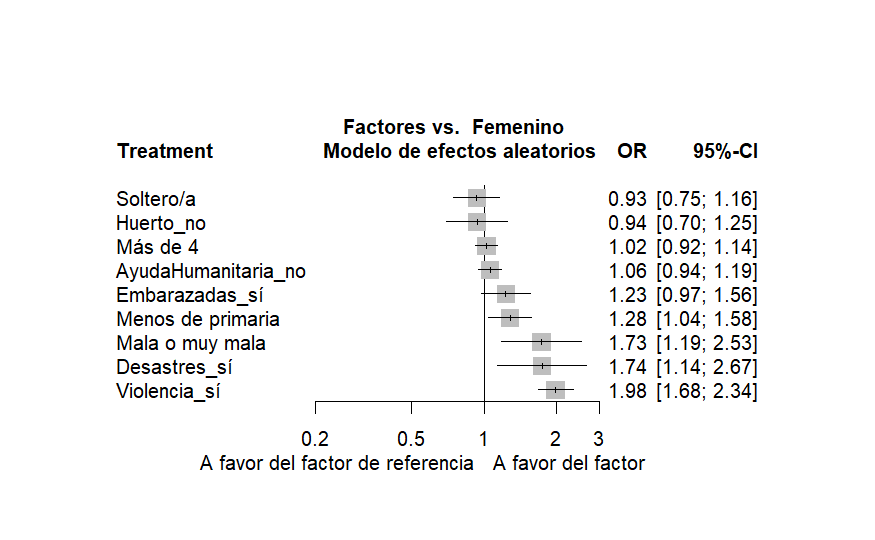

```r
if(modelo_efectos_aleatorios){
  tag <- "Modelo de efectos aleatorios"
}else{
  tag <- "Modelo de efectos fijos"
}

#Descomentar estas líneas para guardarlo como png

#png(file="diagrama_bosque.png")
forest(m.netmeta,
       reference.group = factor_referencia,
       sortvar = TE,
       xlim = c(0.2, 3),
       smlab = paste("Factores vs. ", factor_referencia ,"\n",
                     tag),
       drop.reference.group = TRUE,
       label.left = "A favor del factor de referencia",
       label.right = "A favor del factor") #labels = etiquetas_bonitas)
```

```r
#dev.off()
```

Una de las partes más interesantes del metaanálisis en red es su capacidad para ordenar los factores según la influencia de sus efectos. La función netrank utiliza el P-Score (equivalente a SUCRA) para conseguir una jerarquía de factores. Se debe indicar si los valores pequeños representan algo “bueno” (good) o “malo” (bad) en el criterio de ordenación.

```r
netrank(m.netmeta, small.values = valores_pequenos)
```

```
Title: Modelo de metaanálisis en red

                    P-score
Violencia_sí         0.9400
Mala o muy mala      0.8433
Desastres_sí         0.8432
Menos de primaria    0.6286
Embarazadas_sí       0.5809
AyudaHumanitaria_no  0.3722
Más de 4             0.2863
Femenino             0.2171
Huerto_no            0.1599
Soltero/a            0.1286
```

Gracias a las distribuciones normales que implementa el paquete mvtnorm, podemos crear un rankograma, en el que aparece la probabilidad de cada factor de alcanzar cierto puesto en la jerarquía. Una vez más, se debe indicar el significado de los valores pequeños del efecto. Hay varias formas de representar su salida, por ejemplo, en una tabla de probabilidades:

```r
rankogram(m.netmeta, small.values = valores_pequenos)
```

```
Rankogram (based on 1000 simulations)

Random effects model:

                         1      2      3      4      5      6      7      8      9     10
AyudaHumanitaria_no 0.0000 0.0000 0.0010 0.0130 0.1010 0.4110 0.2360 0.1450 0.0750 0.0180
Desastres_sí        0.2370 0.3030 0.3500 0.0690 0.0280 0.0060 0.0010 0.0030 0.0030 0.0000
Embarazadas_sí      0.0000 0.0130 0.0730 0.3290 0.4120 0.0910 0.0390 0.0160 0.0210 0.0060
Femenino            0.0000 0.0000 0.0000 0.0010 0.0110 0.0970 0.2250 0.3580 0.2460 0.0620
Huerto_no           0.0000 0.0000 0.0020 0.0110 0.0540 0.1080 0.0810 0.0850 0.2070 0.4520
Mala o muy mala     0.2130 0.3050 0.3880 0.0600 0.0260 0.0020 0.0000 0.0030 0.0020 0.0010
Más de 4            0.0000 0.0000 0.0000 0.0020 0.0270 0.1950 0.3280 0.2920 0.1270 0.0290
Menos de primaria   0.0000 0.0090 0.1060 0.5140 0.3160 0.0360 0.0120 0.0030 0.0030 0.0010
Soltero/a           0.0000 0.0000 0.0000 0.0010 0.0250 0.0540 0.0780 0.0950 0.3160 0.4310
Violencia_sí        0.5500 0.3700 0.0800 0.0000 0.0000 0.0000 0.0000 0.0000 0.0000 0.0000
```

También podemos conseguir sus dos gráficas características: la curva de probabilidad acumulada y el gráfico de barras con el puesto de cada factor.

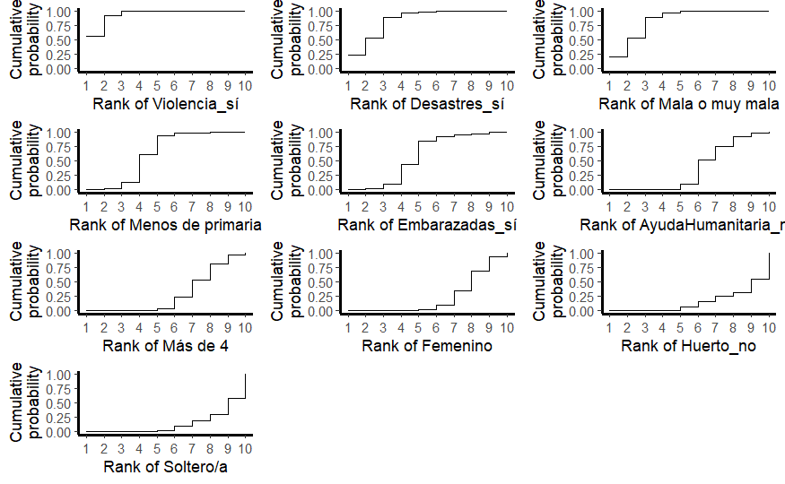

```r
plot(rankogram(m.netmeta, small.values = valores_pequenos, cumulative.rankprob = TRUE))
```

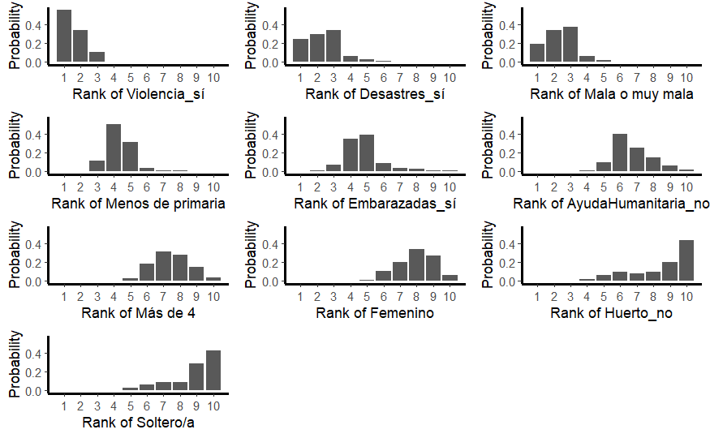

```r
plot(rankogram(m.netmeta, small.values = valores_pequenos, cumulative.rankprob = FALSE))
```